# Factors Lab - Key

Load all the packages we will use in this lab.

```r
library(tidyverse)
```

### 1.0

Load the CalEnviroScreen dataset and use `select` to choose the `CaliforniaCounty`, `ImpWaterBodies`, and `ZIP` variables. Then subset this data using `filter` to include only the California counties Amador, Napa, Ventura, and San Francisco. Name this data “ces”.

`ImpWaterBodies`: measure of the number of pollutants across all impaired water bodies within a given distance of populated areas.

```r
ces <-
  read_csv("https://daseh.org/data/CalEnviroScreen_data.csv") |>
  select(CaliforniaCounty, ImpWaterBodies, ZIP) |>
  filter(CaliforniaCounty %in% c("Amador", "Napa", "Ventura", "San Francisco"))
```

### 1.1

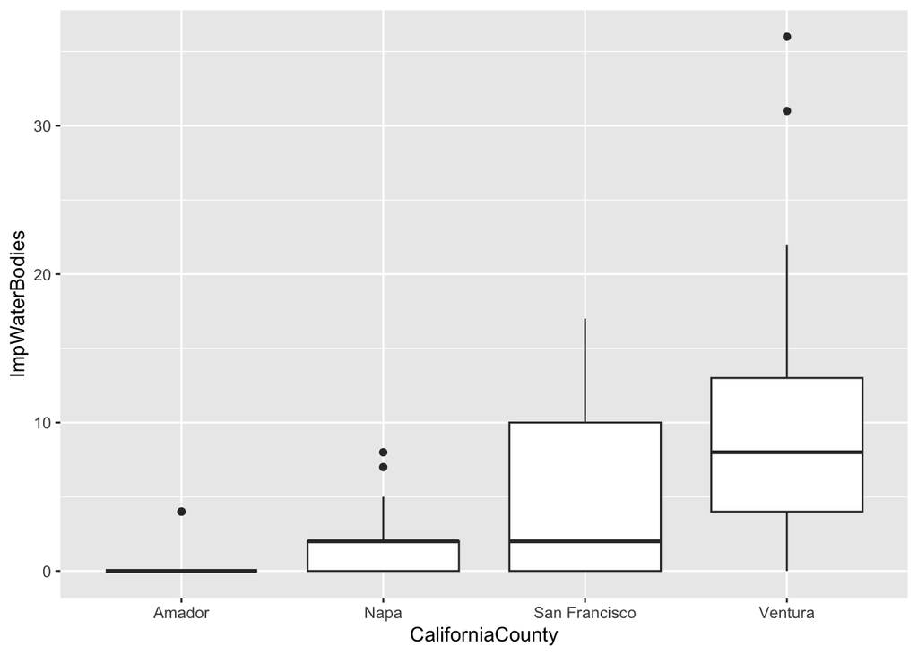

```r
ces |>
  ggplot(aes(x = CaliforniaCounty, y = ImpWaterBodies)) +
  geom_boxplot()
```

### 1.2

Use `count` to count up the number of observations of data for each `CaliforniaCounty` group.

```r
ces |>
  count(CaliforniaCounty)
```

```
## # A tibble: 4 × 2
##   CaliforniaCounty     n
##   <chr>            <int>
## 1 Amador               9
## 2 Napa                40
## 3 San Francisco      195
## 4 Ventura            173
```

### 1.3

Make `CaliforniaCounty` a factor using the `mutate` and `factor` functions. Use the `levels` argument inside `factor` to reorder `CaliforniaCounty`. Reorder this variable so the order is now San Francisco, Ventura, Napa, and Amador. Assign the output the name “ces_fct”.

```r
ces_fct <-
  ces |> mutate(CaliforniaCounty = factor(CaliforniaCounty,
    levels = c("San Francisco", "Ventura", "Napa", "Amador")
  ))
```

### 1.4

Repeat question 1.1 and 1.2 using the “ces_fct” data. You should see different ordering in the plot and `count` table.

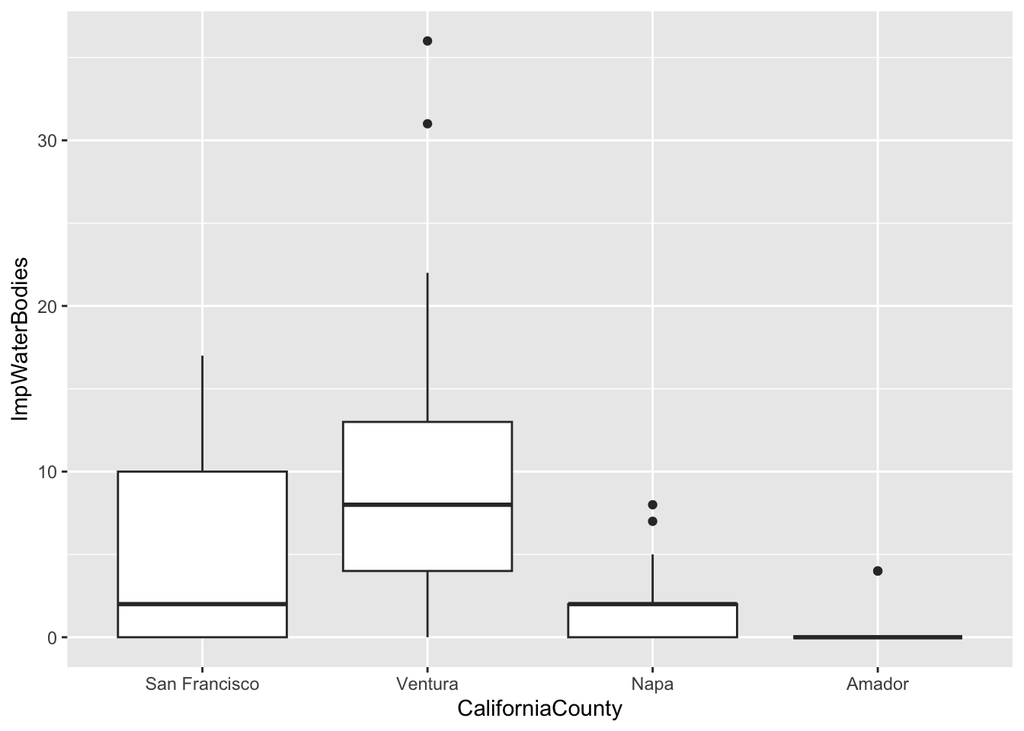

```r
ces_fct |>
  ggplot(aes(x = CaliforniaCounty, y = ImpWaterBodies)) +
  geom_boxplot()
```

```r
ces_fct |>
  count(CaliforniaCounty)
```

```
## # A tibble: 4 × 2
##   CaliforniaCounty     n
##   <fct>            <int>
## 1 San Francisco      195
## 2 Ventura            173
## 3 Napa                40
## 4 Amador               9
```

# Practice on Your Own!

### P.1

Subset `ces_fct` so that it only includes data from Ventura county. Then convert `ZIP` (zip code) into a factor using the `mutate` and `factor` functions. Do not add a `levels =` argument.

```r
ces_Ventura <- ces_fct |>
  filter(CaliforniaCounty == "Ventura") |>
  mutate(ZIP = factor(ZIP))
```

### P.2

We want to create a new column that contains the group-level median values for `ImpWaterBodies`.

- Using the “ces_Ventura” data, group the data by `ZIP` using `group_by`
- Then, use `mutate` to create a new column `med_ImpWaterBodies` that is the median of `ImpWaterBodies`.
- **Hint**: Since you have already done `group_by`, a median `ImpWaterBodies` will automatically be created for each unique level in `ZIP`. Use the `median` function with `na.rm = TRUE`.

```r
ces_Ventura <- ces_Ventura |>
  group_by(ZIP) |>
  mutate(med_ImpWaterBodies = median(ImpWaterBodies, na.rm = TRUE))
```

### P.3

We want to make a plot of the `med_ImpWaterBodies` column we created above in the `ces_Ventura`, separated by `ZIP`. Using the `forcats` package, create a plot that:

- Has `ZIP` on the x-axis
- Uses the `mapping` argument and the `fct_reorder` function to order the x-axis by `med_ImpWaterBodies`
- Has `med_ImpWaterBodies` on the y-axis
- Is a boxplot (`geom_boxplot`)
- Has the x axis label of “Zipcode” (Don’t worry if you get a warning about not being able to plot `NA` values.)

Save your plot using `ggsave()` with a width of 10 and height of 3.

```r
library(forcats)

ces_Ventura_plot <- ces_Ventura |>
  drop_na() |>
  ggplot(aes(
    x = fct_reorder(
      ZIP, med_ImpWaterBodies
    ),
    y = med_ImpWaterBodies
  )) +
  geom_boxplot() +
  labs(x = "Zipcode")

ggsave(
  filename = "ces_Ventura.png", # will save in working directory
  plot = ces_Ventura_plot,
  width = 10, height = 3
)
```